# More Tricks with MATLAB

## Background

Here we will show how we can do many of the tricks we've done in Excel and Mathcad in ohter sections in the class.

Note that we are also ommitting the semi-colon here to increase the "verbosity" (screen output) for this exercise. This is mostly to hopefully enhance the walk-through of this activity.

Let's start with Statistics

## Part 1: Stat-Fu!

Let's take a case with with our age-height problem.

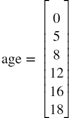

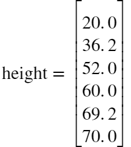

Let's create a input these values into a pair of array....

```matlab
%%%%%%%%%%%%%%%%%%%%%%%%%%%%%%%%%%%%%%%%%%%%%%%%%%%%%%%%%%%%%%%
%
% Initial Values
%
%  here are creating two vertical arrays (note the use of the
%   semicolons between elements.  Thus, these are 1c x 6r
%

age    = [  0.0;  5.0;  8.0; 12.0; 16.0; 18.0 ];
height = [ 20.0; 36.2; 52.0; 60.0; 69.2; 70.0 ];

%
%%%%%%%%%%%%%%%%%%%%%%%%%%%%%%%%%%%%%%%%%%%%%%%%%%%%%%%%%%%%%%%
```

Let's do some basic stats...

```matlab
%%%%%%%%%%%%%%%%%%%%%%%%%%%%%%%%%%%%%%%%%%%%%%%%%%%%%%%%%%%%%%%
%
% Some basic stats (dropping the semocolons so we can see the
%   results as we calculate them...
%

mean_age    = mean(age)
```

mean_age = 9.8333

```matlab
mean_height = mean(height)
```

mean_height = 51.2333

```matlab
%
%%%%%%%%%%%%%%%%%%%%%%%%%%%%%%%%%%%%%%%%%%%%%%%%%%%%%%%%%%%%%%%
```

Now let's implement a linear regression...

If you've had stats with R this hopefully will look familiar. Indeed, I wouldn't want to be a intellectual property lawyer. (I mean, interoperatbility between languages is one thing but....)

```matlab
%%%%%%%%%%%%%%%%%%%%%%%%%%%%%%%%%%%%%%%%%%%%%%%%%%%%%%%%%%%%%%%
%
%  For you R veterans (and soon you ALL will be R veterans)
%    you will find yourself at home here.  We first group
%    our data together into a structure called a table.

data_table = table(age, height)
```

data_table = 6×2 table

|  | age | height |
| --- | --- | --- |
| 1 | 0 | 20.0000 |
| 2 | 5 | 36.2000 |
| 3 | 8 | 52.0000 |
| 4 | 12 | 60.0000 |
| 5 | 16 | 69.2000 |
| 6 | 18 | 70.0000 |

```matlab
% And we can create a regression model or equation

% First we'll set things up for a linear equation...

regression_model_a_h  = 'height ~ age';

% Then we'll set things up for a quadradic solution

regressioh_model_a2_h = 'height ~ age + age^2'
```

regressioh_model_a2_h = 'height ~ age + age^2'

```matlab
%
%%%%%%%%%%%%%%%%%%%%%%%%%%%%%%%%%%%%%%%%%%%%%%%%%%%%%%%%%%%%%%%
```

And yes, R-skateers, this is R-Fu. R has become a working standard in statistics software and you'd be a fool not to borrow it when you can legally get a way with it ;-) I believe there is another [Tom Lehrer song](https://www.youtube.com/watch?v=gXlfXirQF3A) in there somewhere.

Specifically the lead function here is the [fitlim()](https://www.mathworks.com/help/stats/fitlm.html?s_tid=srchtitle) function...

```matlab
%%%%%%%%%%%%%%%%%%%%%%%%%%%%%%%%%%%%%%%%%%%%%%%%%%%%%%%%%%%%%%%
%
%  The fitlm function (JFGI!) is right out of R and does a a
%     "linear" model based on what we have below.  Notice though
%     that it does multivariate fun too!

lm_a  = fitlm(data_table, regression_model_a_h);
lm_a2 = fitlm(data_table, regressioh_model_a2_h);

% some of these fields should be familiar.  For example
%  you can see the correlation coefficient, root mean
%  square error and some others like the St (SST), Sr (SSE)
%  and others.. -- SSR here is your sum{[y(x)-mean(y)]^2} which
%  we didn't play with.

display(lm_a2)
```

lm_a2 =

Linear regression model:  
height ~ 1 + age + age^2  
Estimated Coefficients:  
**Estimate** **SE** **tStat** **pValue**  
**_________** **________** **_______** **_________**  
**(Intercept)** 19.047 2.46 7.7426 0.0044805  
**age** 4.5459 0.61622 7.377 0.0051501  
**age^2** -0.092356 0.032099 -2.8772 0.063673  
Number of observations: 6, Error degrees of freedom: 3  
Root Mean Squared Error: 2.58  
R-squared: 0.99, Adjusted R-Squared 0.983  
F-statistic vs. constant model: 146, p-value = 0.00103

```matlab
display(lm_a)
```

lm_a =

Linear regression model:  
height ~ 1 + age  
Estimated Coefficients:  
**Estimate** **SE** **tStat** **pValue**  
**________** **_______** **______** **_________**  
**(Intercept)** 23.299 3.3022 7.0554 0.0021283  
**age** 2.8408 0.28369 10.014 0.000559  
Number of observations: 6, Error degrees of freedom: 4  
Root Mean Squared Error: 4.33  
R-squared: 0.962, Adjusted R-Squared 0.952  
F-statistic vs. constant model: 100, p-value = 0.000559

```matlab
%
%%%%%%%%%%%%%%%%%%%%%%%%%%%%%%%%%%%%%%%%%%%%%%%%%%%%%%%%%%%%%%%
```

If you just display the output doesn't show everyting that the [fitlim()](https://www.mathworks.com/help/stats/fitlm.html?s_tid=srchtitle) function creates in the resulting [object](https://www.mathworks.com/help/stats/linearmodel-class.html#bsz4dm2-4) it returns.

You can access select values of the [output parameters](https://www.mathworks.com/help/stats/linearmodel-class.html#bsz4dm2-4) following the examples below.

```matlab
%%%%%%%%%%%%%%%%%%%%%%%%%%%%%%%%%%%%%%%%%%%%%%%%%%%%%%%%%%%%%%%
%
% You can pull the individual coefficients.
%

display(lm_a.Coefficients.Estimate)
```

23.2988  
2.8408

```matlab
display(lm_a.Rsquared)
```

Ordinary: 0.9616  
Adjusted: 0.9521

```matlab
display(lm_a.RMSE)
```

4.3288

```matlab
%
%%%%%%%%%%%%%%%%%%%%%%%%%%%%%%%%%%%%%%%%%%%%%%%%%%%%%%%%%%%%%%%
```

And now for plotting, this is nifty

How would you plot this given what we've done? Probably lots of steps because that's what I have to do with other software!

BUT... look at this.

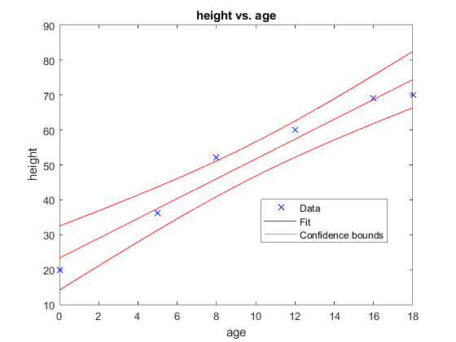

```matlab
%%%%%%%%%%%%%%%%%%%%%%%%%%%%%%%%%%%%%%%%%%%%%%%%%%%%%%%%%%%%%%%
%
% The plotting of these fields.
%
% First there is the linear one.

figure;
plot(lm_a)
```

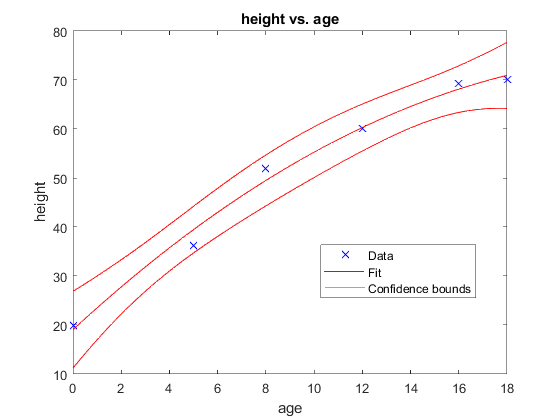

```matlab
%
% Then the quadradic one...
%

figure;
plot(lm_a2)
```

## Part 2: Excel Fu!

Now to get scary. This is new. [But MATLAB can import and export data from Excel](https://www.mathworks.com/discovery/matlab-excel.html). This is only for the Windows version of MATLAB. On other operating systems you can export things as a "comma delimited file" (also called a *.CSV" file)

Specifically there are two functions you can review.

[xlsread](https://www.mathworks.com/help/matlab/ref/xlsread.html?s_tid=srchtitle) to read excel data

[xlwrite](https://www.mathworks.com/help/matlab/ref/xlswrite.html?searchHighlight=xlswrite&s_tid=doc_srchtitle) will write to an excel file

```matlab
%%%%%%%%%%%%%%%%%%%%%%%%%%%%%%%%%%%%%%%%%%%%%%%%%%%%%%%%%%%%%%%
%
% OK now we're going to go off road.  You can also create an excel spradsheet.

%  JGFI xlsread and xlswrite!

%  It's a little scary but it's navigable if you keep your head!

% Let's eat an elephant.  One byte at a time.

%  start with the file name.

filename = './Excel_Age_Height_Regression_Sandbox_With_Matlab.xlsx';  %you can use a full path here

%   Now the first scary part.  You may see orange in text output.

xlswrite(filename,             ... % our file name
         {'Age', 'Height'},    ... % this is our header row (use squigly brakcets!)
         'My_Height_Age_Data', ... % this is the sheet where well stick it
         'A1');                    % and this row/col area is where we start to stick it!
%
%   Let's take a look at that file again before we move on.
%
%%%%%%%%%%%%%%%%%%%%%%%%%%%%%%%%%%%%%%%%%%%%%%%%%%%%%%%%%%%%%%%
```

if all went well you have this spreadsheet in your working directory.

It's just the header line and that's fine (since that's what we asked for...)

[figure not shown]

Now it's braver...

```matlab
%%%%%%%%%%%%%%%%%%%%%%%%%%%%%%%%%%%%%%%%%%%%%%%%%%%%%%%%%%%%%%%
%
% OK now that you're getting braver...

xlswrite(filename,             ... % our file name
         age,                  ... % now we drop our data in (aranged facing "down"
         'My_Height_Age_Data', ... % this is the sheet where well stick it
         'A2');                    % and this row/col area is where we stick it!

xlswrite(filename,             ... % our file name
         height,                  ... % now we drop our data in (aranged facing "down"
         'My_Height_Age_Data', ... % this is the sheet where well stick it
         'B2');                    % and this row/col area is where we stick it!
%
%%%%%%%%%%%%%%%%%%%%%%%%%%%%%%%%%%%%%%%%%%%%%%%%%%%%%%%%%%%%%%%
```

And here is our data in the sheet, all sharable for people who don't use MATLAB!

[figure not shown]

And now to read it!

```matlab
%%%%%%%%%%%%%%%%%%%%%%%%%%%%%%%%%%%%%%%%%%%%%%%%%%%%%%%%%%%%%%%
%
% OK now that you're moving from brave to just getting cocky...
%
% now do you think you can read it?

input_age    = xlsread(filename,             ... % our file name
                       'My_Height_Age_Data',  ... % this is the sheet where well grab it
                       'A2:A7');                  % and this is the FULL range from which we pull it

input_height = xlsread(filename,              ... % our file name
                       'My_Height_Age_Data',  ... % this is the sheet where well grab it
                       'B2:B7');                  % and this is the FULL range from which we pull it


disp(input_age)
```

0  
5  
8  
12  
16  
18

```matlab
disp(input_height)
```

20.0000  
36.2000  
52.0000  
60.0000  
69.2000  
70.0000

```matlab
% and if you can do this, you ain't gonna be afraid of nothin' !!!!
%
%%%%%%%%%%%%%%%%%%%%%%%%%%%%%%%%%%%%%%%%%%%%%%%%%%%%%%%%%%%%%%%
```

... and that's a good thing becasue we're about to do our roots.